# Best New Orleans Restaurants for Picky Eaters in the Yelp Open Dataset

(Notes: the two Waffle Houses in the third table are different locations; restaurants can share a rank if they have the same average rating or adjusted score.)

**Top 20 by original Yelp average rating**

```r
restaurant_scores |> slice_max(raw_mean, n = 20, with_ties = FALSE) |> score_table()
```

| Restaurant | Number of total reviews | Yelp total average rating (raw mean) | Raw rank | Active reviews | Active share | Adjusted score | Adjusted rank | Rank change |
| --- | --- | --- | --- | --- | --- | --- | --- | --- |
| Iacovone Kitchen | 40 | 4.85 | 1 | 13 | 32% | 0.55 | 13 | -12 |
| Cafe Porche and snowbar | 176 | 4.83 | 2 | 7 | 4% | 0.74 | 4 | -2 |
| CIBO | 138 | 4.76 | 3 | 48 | 35% | 0.44 | 35 | -32 |
| Addis Nola | 156 | 4.75 | 4 | 51 | 33% | 0.53 | 16 | -12 |
| The Fat Falafel | 30 | 4.73 | 5 | 11 | 37% | 0.82 | 1 | 4 |
| Capulet | 50 | 4.72 | 6 | 15 | 30% | 0.65 | 7 | -1 |
| Sweet Soulfood | 393 | 4.72 | 7 | 67 | 17% | 0.44 | 34 | -27 |
| Beignets & More | 85 | 4.71 | 8 | 18 | 21% | 0.59 | 11 | -3 |
| Cafe Aquarius | 34 | 4.71 | 8 | 6 | 18% | 0.74 | 2 | 6 |
| Shawarma on the Go | 233 | 4.69 | 10 | 72 | 31% | 0.61 | 8 | 2 |
| I-tal Garden | 34 | 4.68 | 11 | 11 | 32% | 0.49 | 23 | -12 |
| Holy Crepes! | 207 | 4.67 | 12 | 29 | 14% | 0.72 | 5 | 7 |
| Betty’s Bar & Bistro | 46 | 4.65 | 13 | 7 | 15% | -0.01 | 201 | -188 |
| Pepperoni Ray’s Cafe | 42 | 4.62 | 14 | 15 | 36% | 0.41 | 39 | -25 |
| Breads on Oak Cafe & Bakery | 401 | 4.61 | 15 | 110 | 27% | 0.44 | 36 | -21 |
| Bearcat Cafe | 913 | 4.61 | 16 | 242 | 27% | 0.47 | 29 | -13 |
| Good Eden Nola Plantmade | 159 | 4.61 | 17 | 51 | 32% | 0.54 | 14 | 3 |
| Nola Caye | 148 | 4.61 | 18 | 57 | 39% | 0.47 | 30 | -12 |
| Fharmacy Nola | 479 | 4.61 | 19 | 160 | 33% | 0.51 | 19 | 0 |
| Bub’s Nola | 45 | 4.60 | 20 | 28 | 62% | 0.40 | 42 | -22 |

**Top 20 by adjusted score**

```r
restaurant_scores |> slice_max(adj_score, n = 20, with_ties = FALSE) |> score_table()
```

| Restaurant | Number of total reviews | Yelp total average rating (raw mean) | Raw rank | Active reviews | Active share | Adjusted score | Adjusted rank | Rank change |
| --- | --- | --- | --- | --- | --- | --- | --- | --- |
| The Fat Falafel | 30 | 4.73 | 5 | 11 | 37% | 0.82 | 1 | 4 |
| Cafe Aquarius | 34 | 4.71 | 8 | 6 | 18% | 0.74 | 2 | 6 |
| Le Citron Bistro | 47 | 3.81 | 227 | 19 | 40% | 0.74 | 3 | 224 |
| Cafe Porche and snowbar | 176 | 4.83 | 2 | 7 | 4% | 0.74 | 4 | -2 |
| Holy Crepes! | 207 | 4.67 | 12 | 29 | 14% | 0.72 | 5 | 7 |
| Tony Mandina’s | 60 | 4.42 | 49 | 26 | 43% | 0.68 | 6 | 43 |
| Capulet | 50 | 4.72 | 6 | 15 | 30% | 0.65 | 7 | -1 |
| Shawarma on the Go | 233 | 4.69 | 10 | 72 | 31% | 0.61 | 8 | 2 |
| Big Ez Seafood & Wings | 36 | 3.64 | 266 | 7 | 19% | 0.60 | 9 | 257 |
| Moe’s Original Bar B Que | 66 | 4.26 | 91 | 27 | 41% | 0.59 | 10 | 81 |
| Beignets & More | 85 | 4.71 | 8 | 18 | 21% | 0.59 | 11 | -3 |
| Orchid Seafood | 33 | 4.48 | 37 | 14 | 42% | 0.58 | 12 | 25 |
| Iacovone Kitchen | 40 | 4.85 | 1 | 13 | 32% | 0.55 | 13 | -12 |
| Good Eden Nola Plantmade | 159 | 4.61 | 17 | 51 | 32% | 0.54 | 14 | 3 |
| Breads on Oak Cafe & Bakery | 61 | 4.52 | 31 | 9 | 15% | 0.54 | 15 | 16 |
| Addis Nola | 156 | 4.75 | 4 | 51 | 33% | 0.53 | 16 | -12 |
| J’aime Le Cafe | 88 | 4.51 | 32 | 23 | 26% | 0.51 | 17 | 15 |
| Five Guys | 40 | 4.05 | 156 | 19 | 48% | 0.51 | 18 | 138 |
| Fharmacy Nola | 479 | 4.61 | 19 | 160 | 33% | 0.51 | 19 | 0 |
| Fiorella’s the Original | 133 | 4.44 | 45 | 60 | 45% | 0.50 | 20 | 25 |

**Biggest rank changes**

```r
restaurant_scores |> slice_max(abs(rank_change), n = 20, with_ties = FALSE) |> score_table()
```

| Restaurant | Number of total reviews | Yelp total average rating (raw mean) | Raw rank | Active reviews | Active share | Adjusted score | Adjusted rank | Rank change |
| --- | --- | --- | --- | --- | --- | --- | --- | --- |
| Waffle House | 30 | 3.30 | 316 | 7 | 23% | 0.35 | 54 | 262 |
| Big Ez Seafood & Wings | 36 | 3.64 | 266 | 7 | 19% | 0.60 | 9 | 257 |
| Nola Vegan | 36 | 4.56 | 27 | 7 | 19% | -0.17 | 256 | -229 |
| Le Citron Bistro | 47 | 3.81 | 227 | 19 | 40% | 0.74 | 3 | 224 |
| Chick-fil-A | 80 | 3.14 | 332 | 29 | 36% | 0.15 | 116 | 216 |
| Raising Cane’s Chicken Fingers | 32 | 3.12 | 335 | 11 | 34% | 0.09 | 136 | 199 |
| Waffle House | 31 | 3.13 | 334 | 7 | 23% | 0.08 | 143 | 191 |
| Betty’s Bar & Bistro | 46 | 4.65 | 13 | 7 | 15% | -0.01 | 201 | -188 |
| Applebee’s Grill + Bar | 53 | 2.53 | 364 | 12 | 23% | 0.02 | 179 | 185 |
| Nola Crawfish King Seafood & Barbecue | 43 | 4.16 | 127 | 13 | 30% | -0.32 | 306 | -179 |
| Pizza Hut | 30 | 1.90 | 383 | 6 | 20% | -0.04 | 211 | 172 |
| Mayhew Bakery | 31 | 4.39 | 58 | 11 | 35% | -0.06 | 220 | -162 |
| Smiley’s Grill | 94 | 3.71 | 244 | 18 | 19% | 0.25 | 83 | 161 |
| La Macarena Pupuseria & Latin Cafe | 353 | 4.20 | 111 | 75 | 21% | -0.20 | 271 | -160 |
| Papa’s Pizza | 38 | 3.76 | 232 | 7 | 18% | -1.40 | 392 | -160 |
| Parran’s Poboys | 56 | 3.73 | 239 | 19 | 34% | 0.25 | 81 | 158 |
| Willie’s Chicken Shack | 216 | 3.62 | 270 | 19 | 9% | 0.15 | 114 | 156 |
| Rampart Treehouse | 32 | 4.12 | 139 | 11 | 34% | -0.27 | 294 | -155 |
| Beaucoup Eats | 68 | 3.91 | 201 | 19 | 28% | 0.37 | 48 | 153 |
| Marjie’s Grill | 173 | 4.32 | 73 | 50 | 29% | -0.07 | 223 | -150 |

**Raw vs adjusted**

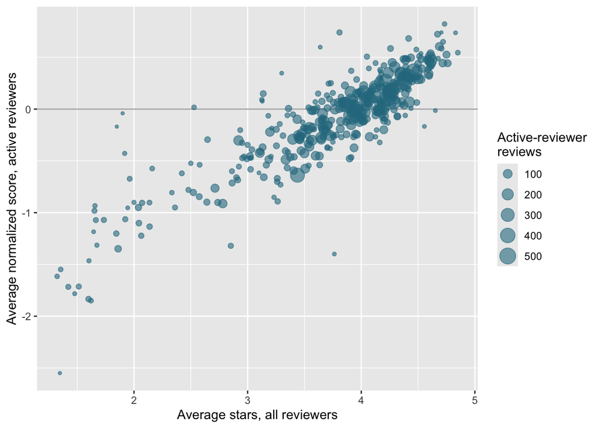

```r
ggplot(restaurant_scores, aes(raw_mean, adj_score, size = n_active)) +
  geom_hline(yintercept = 0, color = "grey70") +
  geom_point(alpha = 0.6, color = viridis(1, begin = 0.4)) +
  labs(x = "Average stars, all reviewers",
       y = "Average normalized score, active reviewers",
       size = "Active-reviewer\nreviews")
```

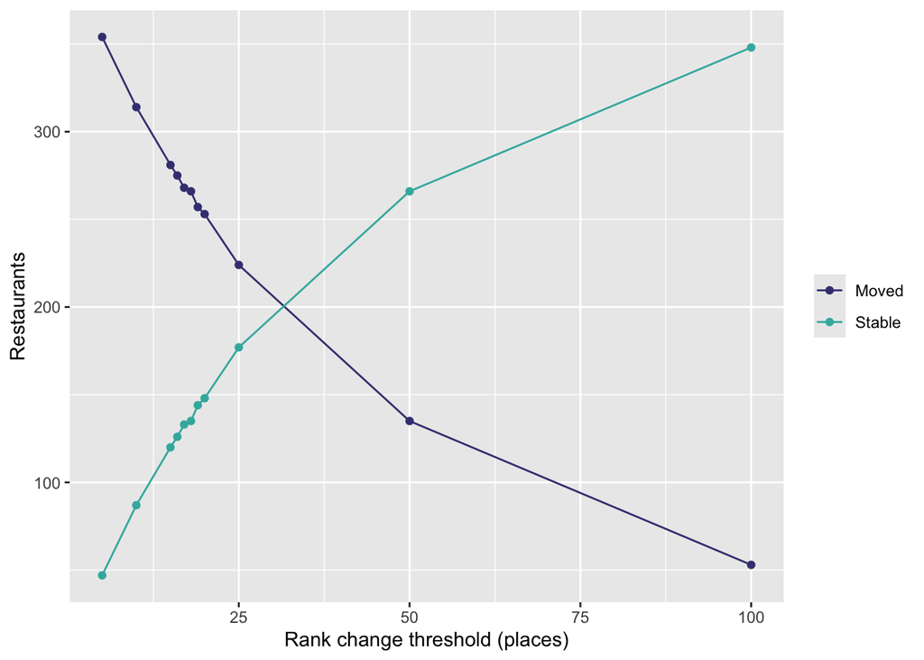

```r
# show restaurants that moved by various amounts
mover_counts <- map(c(100, 50, 25, 20, 19, 18, 17, 16, 15, 10, 5), \(k) {
  tibble(
    Threshold = k,
    Moved     = sum(abs(restaurant_scores$rank_change) >= k),
    Stable    = sum(abs(restaurant_scores$rank_change) <  k)
  )
}) |>
  list_rbind()

# plot it
mover_counts |>
  pivot_longer(-Threshold, names_to = "group", values_to = "restaurants") |>
  ggplot(aes(Threshold, restaurants, color = group)) +
  geom_line() +
  geom_point() +
  scale_color_manual(values = mako(2, begin = 0.3, end = 0.7)) +
  labs(x = "Rank change threshold (places)", y = "Restaurants", color = NULL)
```

[^1]: Based on adjusted scores, not relevant phrases, since there are so few mentions of relevant phrases in the data.

## Top 10 restaurants

Requiring at least 5 reviews from active reviewers removed only 1 restaurant from the category group. The chart shows how many scored restaurants each ZIP code has; the 14 ZIP codes with at least 10 get a top 10 list.

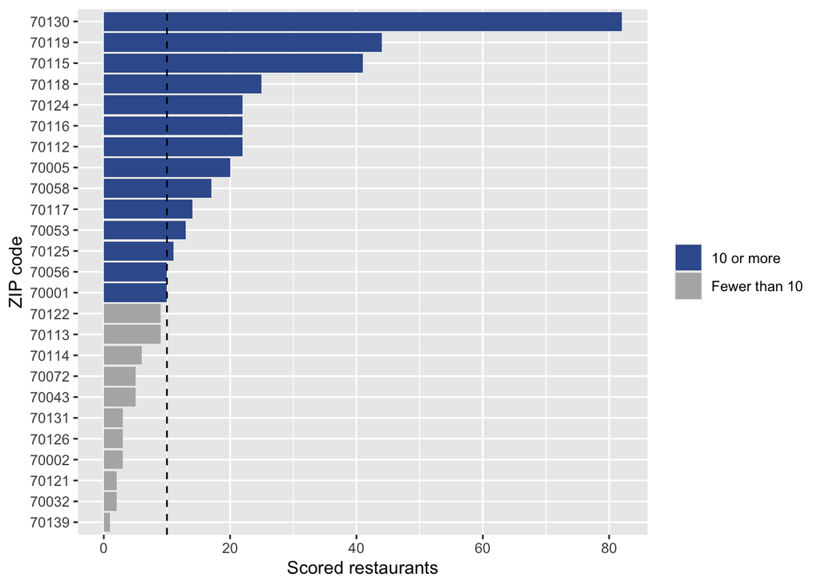

```r
count(scored_zip, area_id) |>
  mutate(area_id = fct_reorder(area_id, n),
         has_top10 = if_else(n >= 10, "10 or more", "Fewer than 10")) |>
  ggplot(aes(n, area_id, fill = has_top10)) +
  geom_col() +
  geom_vline(xintercept = 10, linetype = "dashed") +
  scale_fill_manual(values = c("10 or more" = mako(1, begin = 0.4), "Fewer than 10" = "grey70")) +
  labs(x = "Scored restaurants", y = "ZIP code", fill = NULL)
```

```r
top10 <- qualified |>
  slice_max(adj_score, n = 10, with_ties = FALSE, by = area_id) |>
  mutate(rank = row_number(desc(adj_score)), .by = area_id)

# order restaurants in each ZIP by rank
top10 <- arrange(top10, area_id, rank)

# save results for the top-of-report summary
answer_zips <- qualified |> count(area_id, sort = TRUE) |> slice_head(n = 7) |> pull(area_id)

top10 |>
  filter(area_id %in% answer_zips) |>
  arrange(match(area_id, answer_zips), rank) |>
  saveRDS(file.path(out_dir, "top10.rds"))
```

The tabs below list the top 10 restaurants in each of the 14 ZIP codes; the map at the top of the report shows where they are.

**70001**

| Rank | Restaurant | Address | Raw mean | Adjusted score |
| --- | --- | --- | --- | --- |
| 1 | Moe’s Original Bar B Que | 1101 N Causeway Blvd | 4.26 | 0.59 |
| 2 | Waffle House | 3616 Airline Dr | 3.30 | 0.35 |
| 3 | Mantra Indian Cuisine | 3116 S I-10 Service Rd E | 4.42 | 0.19 |
| 4 | Chef Ron’s Gumbo Stop | 2309 N Causeway Blvd | 4.42 | 0.07 |
| 5 | LOFT18- Metairie | 3128 Metairie Rd | 3.76 | 0.06 |
| 6 | Ristorante Filippo | 1917 Ridgelake Dr | 3.61 | 0.02 |
| 7 | Tic Toc Cafe | 3205 36th St | 3.74 | -0.11 |
| 8 | Jam’s PO-Boys & Catering | 2701 Airline Hwy | 3.70 | -0.38 |
| 9 | Fat Boys Pizza | 2565 Metairie Rd | 3.38 | -0.46 |
| 10 | McDonald’s | 2700 Airline Dr | 1.32 | -1.62 |

**70005**

| Rank | Restaurant | Address | Raw mean | Adjusted score |
| --- | --- | --- | --- | --- |
| 1 | Nor-Joe Imports | 505 Frisco Ave | 4.37 | 0.48 |
| 2 | Po-Boy King | 805 Homestead Ave | 4.17 | 0.38 |
| 3 | Radosta’s Restaurant | 249 Aris Ave | 4.31 | 0.25 |
| 4 | Giorlando’s Restaurant | 741 Bonnabel Blvd | 3.98 | 0.17 |
| 5 | Fury’s Restaurant | 724 Martin Behrman Ave | 3.75 | 0.16 |
| 6 | Zoes Kitchen | 701 Metairie Rd, Ste 1A103 | 3.65 | 0.07 |
| 7 | Mark Twain’s Pizza Landing | 2035 Metairie Rd | 3.83 | 0.07 |
| 8 | Fausto’s Bistro | 530 Veterans Memorial Blvd | 4.06 | 0.05 |
| 9 | Applebee’s Grill + Bar | 1000 West Esplanade Ave | 2.53 | 0.02 |
| 10 | Desi Vega’s Seafood and Prime Steaks | 111 Veterans Blvd, Ste 150 | 3.89 | -0.02 |

**70053**

| Rank | Restaurant | Address | Raw mean | Adjusted score |
| --- | --- | --- | --- | --- |
| 1 | Tony Mandina’s | 1915 Pratt St | 4.42 | 0.68 |
| 2 | Banana Blossom | 500 9th St | 4.24 | 0.35 |
| 3 | Big EZ Seafood | 1632 Lafayette St | 4.32 | 0.26 |
| 4 | Cafe 615 Home of Da Wabbit | 615 Kepler St | 4.09 | 0.19 |
| 5 | Ground Pati Grille & Bar | 11 Westbank Expy | 3.18 | -0.06 |
| 6 | Common Grounds Coffeehouse & Cafe | 335 Huey P Long Ave | 3.65 | -0.19 |
| 7 | Gretna Depot Cafe & Spirits | 326 Huey P Long Ave | 3.31 | -0.26 |
| 8 | Gattuso’s Neighborhood Restaurant & Bar | 435 Huey P Long Ave | 3.46 | -0.29 |
| 9 | The Red Maple | 1036 Lafayette St | 3.25 | -0.35 |
| 10 | Roundhouse Bar & Grill | 275 Whitney Ave | 2.50 | -0.52 |

**70056**

| Rank | Restaurant | Address | Raw mean | Adjusted score |
| --- | --- | --- | --- | --- |
| 1 | Shawarma On The Run | 93 Terry Pkwy | 4.53 | 0.48 |
| 2 | Dimartino’s Famous New Orleans Muffulettas | 1788 Carol Sue Ave | 3.96 | 0.29 |
| 3 | Sun Ray Grill | 2600 Belle Chasse Hwy | 4.00 | 0.14 |
| 4 | Reginelli’s Pizzeria | 1700 Belle Chasse Hwy, Bldg. B, Suite 130 | 3.72 | 0.10 |
| 5 | Specialty Italian Bistro | 2330 Belle Chasse Hwy | 3.53 | -0.26 |
| 6 | Fuji Hana Sushi Bar and Hibachi Steakhouse | 1130 Behrman Hwy | 3.47 | -0.26 |
| 7 | Wingstop | 651 Terry Pkwy | 2.65 | -0.29 |
| 8 | New Orleans Hambuger & Seafood | 197 Westbank Expy | 3.73 | -0.38 |
| 9 | Waffle House | 559 Behrman Hwy | 2.36 | -0.95 |
| 10 | IHOP | 151 Westbank Expy | 1.84 | -1.20 |

**70058**

| Rank | Restaurant | Address | Raw mean | Adjusted score |
| --- | --- | --- | --- | --- |
| 1 | Big Ez Seafood & Wings | 2245 Manhattan Blvd, Ste 105 | 3.64 | 0.60 |
| 2 | Five Guys | 1523 Manhattan Blvd | 4.05 | 0.51 |
| 3 | Cleopatra Restaurant | 2701 Manhattan Blvd, Ste 24 | 4.50 | 0.44 |
| 4 | Home Cooking Cafe | 2104 Manhattan Blvd, Ste E | 4.59 | 0.38 |
| 5 | New Orleans Food and Spirits | 2330 Lapalco Blvd, Ste 13 | 4.16 | 0.22 |
| 6 | Chick-fil-A | 1128 Manhattan Blvd | 3.14 | 0.15 |
| 7 | The Spud Spot | 1818 Manhattan Blvd, Ste 9 | 4.05 | 0.14 |
| 8 | Zea Rotisserie & Bar | 1121 Manhattan Blvd | 3.92 | 0.03 |
| 9 | Big Poppa Burgers | 3300 4th St | 3.35 | -0.06 |
| 10 | New Orleans Hamburger & Seafood Co. | 2515 B Manhattan Blvd | 3.68 | -0.10 |

**70112**

| Rank | Restaurant | Address | Raw mean | Adjusted score |
| --- | --- | --- | --- | --- |
| 1 | Two Chicks Café - CBD | 920 Gravier St | 4.59 | 0.49 |
| 2 | Reginelli’s Pizzeria | 930 Poydras St, Suite 100 | 3.86 | 0.23 |
| 3 | Vegan Wit A Twist | 514 S Rampart St | 4.35 | 0.20 |
| 4 | Crescent City Pizza Works | 407 Bourbon St | 4.31 | 0.09 |
| 5 | Cleo’s | 940 Canal St | 4.22 | 0.07 |
| 6 | P & G Restaurant & Bar | 345 Baronne St | 4.17 | 0.05 |
| 7 | Powdered Sugar | 800 Iberville St | 3.86 | 0.02 |
| 8 | Deanie’s Seafood | 841 Iberville St | 3.66 | -0.04 |
| 9 | Palm&Pine | 308 N Rampart St | 4.32 | -0.07 |
| 10 | Willie Mae’s At The Market | 234 Loyola Ave | 4.14 | -0.20 |